# Poverty and Test Performance in New York Public Schools

Descriptive analysis of supplied school and county data, 2009–2016

## Purpose and scope

The education department wants to understand whether schools serving more disadvantaged communities show lower achievement, whether these differences change over time, and whether lunch eligibility helps explain the pattern. These questions can inform where further investigation and support are needed.

The supplied files cover **New York State**, not only New York City. This report uses the statewide sample. School records span 2008–2017; ACS records span 2009–2016. Analyses involving poverty use matched records in the common years. County poverty describes community conditions, not the poverty status of each student. Lunch variables measure **eligibility**, not meals received or access to a particular intervention.

Useful displays include county-year summaries, comparisons of poverty groups, annual relative-score trends, and school-level lunch eligibility scatterplots. These data can support descriptive comparisons; they cannot by themselves establish what causes score differences or estimate the effect of providing meals.

## Workflow and analytical choices

1. `1_clean.R` imports the raw files, inspects their structure, converts numeric and text `-99` values and blank text to missing values, removes 24 exact duplicate rows, and excludes 86 records with invalid lunch proportions. Other missing values do not automatically cause a row to be deleted. The cleaned school file contains 35,553 school-year records.
2. `2_transform.R` splits counties into approximately equal poverty thirds within each year (21 low, 21 medium, 20 high). This compares relative poverty positions; thresholds and membership can change over time, and `ntile()` can split tied values. It standardizes both scores within year using `scale()`, then uses a left join on county and year. Unmatched school rows remain in the merged file with missing county indicators.
3. `3_analyze.R` limits poverty analyses to matched records, computes county-year tables, and uses 2016 for the five highest/lowest poverty comparisons.
4. `4_plot.R` saves the figures below. `run_all.R` runs all scripts and renders this notebook to a self-contained HTML file.

**Aggregation.** Enrollment is summed within county-year, never across years. Lunch eligibility is enrollment-weighted using only schools with observed eligibility and positive enrollment in both numerator and denominator. Because school proportions may be rounded, this is an estimate. County score means weight observed schools equally; poverty-group means then weight counties equally. They are not student-weighted averages of individual test results. Missing scores are omitted for the relevant subject; school counts and lunch enrollment coverage are included in the full CSV tables.

**Standardization.** A z-score of zero is the mean of observed school scores in that year’s cleaned statewide school sample; one unit is one standard deviation. These scores measure relative standing, not absolute learning gains. The county means need not average to zero because counties are weighted equally.

| Year | School records | Matched | Unmatched |
| --- | --- | --- | --- |
| 2008 | 3510 | 0 | 3510 |
| 2009 | 3520 | 3520 | 0 |
| 2010 | 3572 | 3572 | 0 |
| 2011 | 3583 | 3583 | 0 |
| 2012 | 3537 | 3537 | 0 |
| 2013 | 3505 | 3505 | 0 |
| 2014 | 3579 | 3578 | 1 |
| 2015 | 3578 | 3570 | 8 |
| 2016 | 3600 | 3600 | 0 |
| 2017 | 3569 | 0 | 3569 |

## County summaries

The full county-by-year table is saved in `outputs/tables/county_year_summary.csv`. Below is its latest-year snapshot, covering all counties in the matched data. Totals describe schools retained in this dataset, not a separately verified census of every student in the county.

County summary: 2016

| County | Enrollment | Lunch eligible | County poverty | Lunch coverage |
| --- | --- | --- | --- | --- |
| ALBANY | 25,895 | 40.7% | 12.3% | 100.0% |
| ALLEGANY | 5,569 | 57.2% | 15.3% | 100.0% |
| BRONX | 178,274 | 84.2% | 29.8% | 100.0% |
| BROOME | 18,560 | 53.8% | 16.5% | 100.0% |
| CATTARAUGUS | 9,051 | 54.4% | 16.9% | 100.0% |
| CAYUGA | 5,727 | 48.9% | 10.8% | 100.0% |
| CHAUTAUQUA | 13,445 | 57.1% | 18.5% | 100.0% |
| CHEMUNG | 9,054 | 53.1% | 15.0% | 100.0% |
| CHENANGO | 5,576 | 55.2% | 15.2% | 100.0% |
| CLINTON | 7,053 | 51.8% | 14.6% | 100.0% |
| COLUMBIA | 4,409 | 49.2% | 12.3% | 100.0% |
| CORTLAND | 3,561 | 55.3% | 12.7% | 100.0% |
| DELAWARE | 4,578 | 56.8% | 15.0% | 100.0% |
| DUTCHESS | 24,365 | 32.9% | 8.6% | 100.0% |
| ERIE | 92,984 | 47.9% | 14.3% | 100.0% |
| ESSEX | 2,909 | 53.5% | 9.4% | 100.0% |
| FRANKLIN | 5,177 | 59.0% | 17.1% | 100.0% |
| FULTON | 5,674 | 56.3% | 16.3% | 100.0% |
| GENESEE | 4,975 | 46.4% | 12.3% | 100.0% |
| GREENE | 4,282 | 49.7% | 12.1% | 100.0% |
| HAMILTON | 471 | 44.1% | 11.2% | 100.0% |
| HERKIMER | 6,465 | 54.6% | 13.7% | 100.0% |
| JEFFERSON | 13,256 | 50.4% | 13.8% | 100.0% |
| KINGS | 249,479 | 72.0% | 22.5% | 100.0% |
| LEWIS | 3,214 | 51.6% | 13.8% | 100.0% |
| LIVINGSTON | 4,818 | 43.4% | 13.5% | 100.0% |
| MADISON | 6,386 | 48.0% | 11.0% | 100.0% |
| MONROE | 76,701 | 48.3% | 14.4% | 100.0% |
| MONTGOMERY | 4,903 | 57.2% | 20.2% | 100.0% |
| NASSAU | 133,773 | 28.9% | 5.9% | 100.0% |
| NEW YORK | 115,541 | 65.0% | 17.1% | 100.0% |
| NIAGARA | 19,016 | 52.2% | 13.4% | 100.0% |
| ONEIDA | 23,126 | 58.1% | 15.8% | 100.0% |
| ONONDAGA | 47,421 | 48.8% | 14.6% | 100.0% |
| ONTARIO | 11,628 | 38.1% | 10.0% | 100.0% |
| ORANGE | 40,241 | 44.7% | 12.3% | 100.0% |
| ORLEANS | 3,910 | 57.5% | 14.5% | 100.0% |
| OSWEGO | 13,082 | 56.9% | 17.5% | 100.0% |
| OTSEGO | 5,557 | 47.2% | 14.9% | 100.0% |
| PUTNAM | 9,433 | 20.8% | 5.1% | 100.0% |
| QUEENS | 220,325 | 69.0% | 14.5% | 100.0% |
| RENSSELAER | 13,327 | 47.8% | 11.9% | 100.0% |
| RICHMOND | 46,094 | 57.0% | 12.8% | 100.0% |
| ROCKLAND | 26,253 | 37.5% | 14.3% | 100.0% |
| SAINT LAWRENCE | 11,368 | 55.6% | 17.1% | 100.0% |
| SARATOGA | 21,850 | 24.0% | 6.3% | 100.0% |
| SCHENECTADY | 14,158 | 49.8% | 11.7% | 100.0% |
| SCHOHARIE | 3,142 | 53.6% | 13.5% | 100.0% |
| SCHUYLER | 1,023 | 52.4% | 14.3% | 100.0% |
| SENECA | 2,637 | 31.6% | 11.3% | 100.0% |
| STEUBEN | 9,964 | 53.1% | 14.8% | 100.0% |
| SUFFOLK | 156,732 | 38.5% | 7.1% | 100.0% |
| SULLIVAN | 6,174 | 51.9% | 16.5% | 100.0% |
| TIOGA | 5,272 | 55.3% | 10.9% | 100.0% |
| TOMPKINS | 7,916 | 43.6% | 17.4% | 100.0% |
| ULSTER | 14,853 | 47.1% | 12.5% | 100.0% |
| WARREN | 6,216 | 41.2% | 10.9% | 100.0% |
| WASHINGTON | 5,193 | 51.5% | 12.2% | 100.0% |
| WAYNE | 9,845 | 51.0% | 11.7% | 100.0% |
| WESTCHESTER | 105,793 | 39.4% | 9.6% | 100.0% |
| WYOMING | 2,085 | 45.7% | 10.5% | 100.0% |
| YATES | 1,364 | 57.1% | 13.2% | 100.0% |

### Five lowest- and highest-poverty counties

Raw scores are compared **within the same year** in this table. ELA and math use different test scales and should not be compared numerically to each other.

Poverty extremes: 2016

| Group | County | Poverty | Lunch eligible | Mean ELA | Mean math |
| --- | --- | --- | --- | --- | --- |
| Lowest 5 | PUTNAM | 5.1% | 20.8% | 312.0 | 313.3 |
| Lowest 5 | NASSAU | 5.9% | 28.9% | 316.8 | 320.2 |
| Lowest 5 | SARATOGA | 6.3% | 24.0% | 312.3 | 318.3 |
| Lowest 5 | SUFFOLK | 7.1% | 38.5% | 306.5 | 307.6 |
| Lowest 5 | DUTCHESS | 8.6% | 32.9% | 302.8 | 301.8 |
| Highest 5 | BRONX | 29.8% | 84.2% | 295.8 | 291.0 |
| Highest 5 | KINGS | 22.5% | 72.0% | 303.7 | 300.8 |
| Highest 5 | MONTGOMERY | 20.2% | 57.2% | 289.5 | 293.2 |
| Highest 5 | CHAUTAUQUA | 18.5% | 57.1% | 297.4 | 300.4 |
| Highest 5 | OSWEGO | 17.5% | 56.9% | 294.4 | 302.3 |

## Question 1: How does performance differ by poverty group?

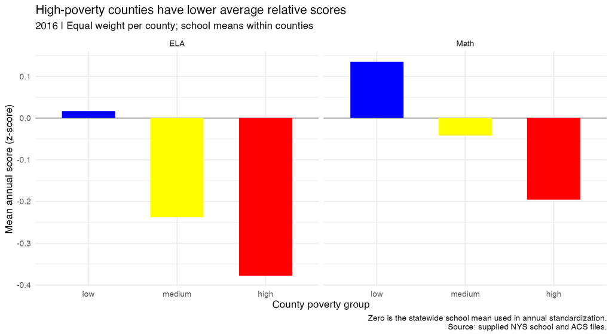

In 2016, the high-poverty group’s county-average score was 0.39 standard deviations below the low-poverty group for ELA and 0.33 below for math. The middle group lay between them in both subjects. This is a descriptive association between county poverty and school performance, not evidence that county poverty alone caused the differences.

## Question 2: Has the relationship changed over time?

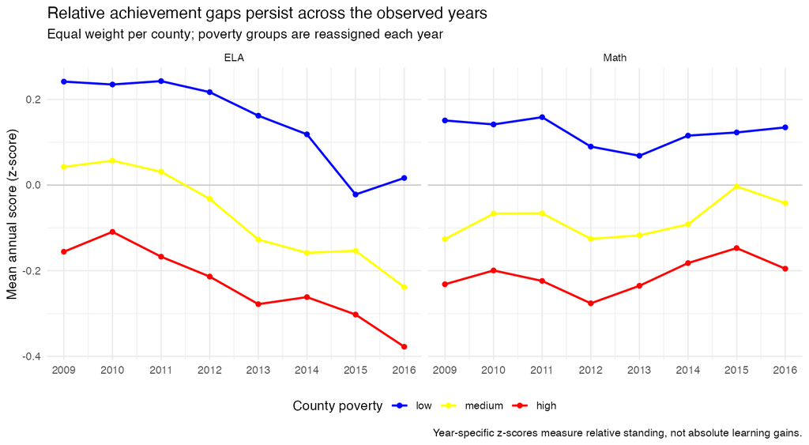

The high-poverty group scored below the low-poverty group in both subjects in every observed year. The ELA high-minus-low gap was -0.40 in 2009 and -0.39 in 2016; the math gap was -0.38 and -0.33, respectively. Gaps fluctuated rather than narrowing steadily. Changes in poverty-group membership, school composition and testing can contribute to the pattern; annual standardization does not make these measures absolute achievement trends.

| Year | ELA: high minus low | Math: high minus low |
| --- | --- | --- |
| 2009 | -0.397 | -0.383 |
| 2010 | -0.344 | -0.341 |
| 2011 | -0.410 | -0.383 |
| 2012 | -0.431 | -0.366 |
| 2013 | -0.440 | -0.304 |
| 2014 | -0.380 | -0.298 |
| 2015 | -0.280 | -0.270 |
| 2016 | -0.394 | -0.330 |

## Question 3: What does lunch eligibility tell us?

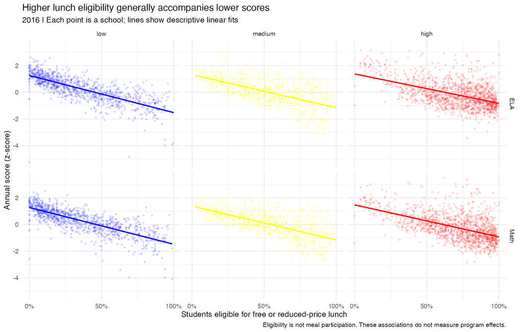

Within each county poverty group in 2016, schools with higher lunch eligibility generally had lower scores. The correlations below use complete school-level pairs. This pattern is consistent with eligibility also capturing student socioeconomic disadvantage within counties.

| County poverty group | Subject | Schools | Correlation |
| --- | --- | --- | --- |
| low | ELA | 1022 | -0.757 |
| medium | ELA | 1015 | -0.582 |
| high | ELA | 1323 | -0.511 |
| low | Math | 1022 | -0.764 |
| medium | Math | 1014 | -0.634 |
| high | Math | 1323 | -0.527 |

**The moderation question remains unresolved.** Separate scatterplots and correlations do not test whether lunch eligibility changes the association between poverty and performance. That would require a specified interaction analysis and attention to confounding and repeated observations. Further, eligibility is not actual meal participation: these results do not show whether providing free or reduced-price lunch improves or harms performance.

## Interpretation and limitations

The descriptive results identify persistent achievement differences that merit further investigation. They do not justify reducing meal support or treating poverty as a complete explanation of school performance. A next study could combine participation data with student characteristics and school resources to examine possible mechanisms.

The 86 excluded lunch-anomaly records may be concentrated in particular years or schools, so their small overall share does not guarantee no selection bias. Missing-score exclusions can also change comparisons. County poverty is an aggregate measure, school scores are averages, and this analysis provides no formal uncertainty estimates or causal identification.

*Review note:* These written interpretations are an AI-assisted draft based on the generated tables. The student should check the calculations and express their own takeaways before submission, consistent with the course’s AI guidance.

## Reproducibility

Open `Capstone.Rproj` and run `source("run_all.R")` from a fresh R session. The scripts use project-relative paths and leave original files unchanged. The README lists dependencies and outputs.